# 2.07-Binary-Search-Trees

### Remove Node - Two Children

The most difficult scenario between the three, but also the most interesting, is when we have to remove a node that has two children. But why would that be so hard to do? Well, let's have a look.

Let's say that from this tree we want to remove `15`.We saw until now that the way to remove a node was to basically make its parent point to either none or to one of its children. But what if we were to apply the same logic to our node here? To which child should we point its parent? Do we point `29` to `22`?

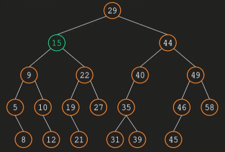

We Could, But what happens to this other branch? It will basically be removed from the tree (refer below).

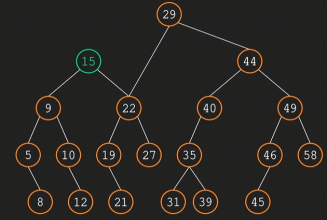

Should we make a connection from `9` to `29` then? Well, we can't, because if we did, this wouldn't be a binary tree any more.

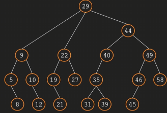

So we need a different approach. The secret is to find a replacement for the removed node. We need to find another node that's in the tree that could replace `15` without breaking the rule of beingless than its entire right side, and greater than its left side. And we have more than one to choose from. To better understand how we can identify them, I think it's time to introduce two new terms the **successor** and the **predecessor**.

The successor is the node with the next larger value in the tree. In our example, the successor of `15` is `19`.That's the next node greater than `15`.The predecessor is the node with the next smaller value for `15`, that will be `12`.If we take another example, like `44`, its successor will be `45`.And the predecessor `40`. But for our purpose, which is to replace the node we remove, we won't need to find both of them. Only one would be just fine

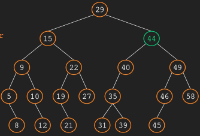

**what is the logic of finding the successor?**

The steps are as follows :

Example 1 - From the target node (`15`), we need to navigate to the right only once(`22`). And then if we have a left child (`19`), we need to **keep going to the left until we can't any more**. In this case, **we only went one time because `19` does not have a left child**. And when we reach the end, we don't go to the right anymore. We stop. Even if this is not a leaf node, it doesn't matter. We don't want to reach the end of the branch. **We want to go only to the left as much as possible. And when we can't any more, we found our successor**.

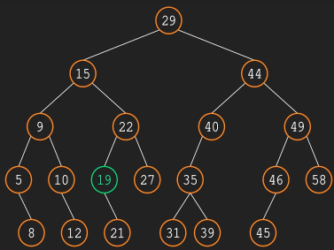

We found the replacement, but we still don't know how to remove the node and put its successor in its place.

Well, the trick is to do it in reverse order. We don't need to first remove and then replace. We can replace first and afterwards remove. Remember, the nodes themselves are just containers. What's inside them is what matters. So what we can do is to replace the value inside the node we want to remove with the value from the successor. So now we have the replacement in place (`31`)

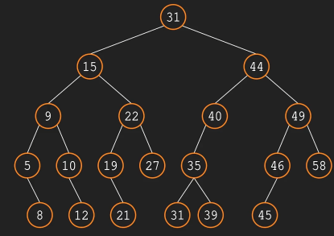

but the old successor node is still in the tree (`31`).What we can do to address that might again not be very intuitive. Instead of writing some logic to remove the node, which will be more or less a duplication of what we already have, we can just `recursively call` the remove method on the old successor, and that will take care of locating and removing the node. And that's it

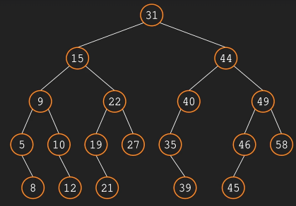

**Why Go Leftmost After Right?**

✅ The `in-order successor` of a node is `the smallest value in the right subtree`.

✅ To find this `smallest value`, we `first move right` (to access larger values) and then `go left as far as possible` (to find the smallest among them)

Example 50 / \ 30 70 / \ 60 80

✅ If removing 50, we move `right to 70` (its right child).

✅ Then, we `go left until we reach the smallest node` (60).

✅ `60 becomes the replacement for 50`, ensuring BST rules remain valid.

We need a value that’s the `next larger than the node being deleted` — which, by definition, `lives in the right subtree`. The `leftmost node in the right subtree` is the `smallest of the values larger than the node`, making it the in-order successor.

**Could We Use the Left Subtree Instead?**

Yes, we technically can — by picking the in-order predecessor, which is the rightmost node in the left subtree. It’s just a different strategy, and both are valid. But most implementations prefer the successor because:

- It’s often easier to find and delete (especially if it's a leaf or has just one child).
- Traversal code is slightly more intuitive going leftward from the right child.

```python
 @staticmethod
def _get_successor(current): # Need a value larger than node being deleted, which lives in the right subtree.
# The leftmost node in the right subtree is the smallest of the values larger than the node, making it the in-order successor.
# The successor we are adopting(in-order successor vs predecessor) should be Higher than current (go right) but lower than right child (now go left)
    """Finds the successor (smallest node in the right subtree)."""
    successor = current.right # Start from the right child of the current node(to access larger values - right of root)
    while successor and successor.left: # 1.Check if successor exists(not None) & 2.checks if successor.left exists.
        successor = successor.left # Move left until we find the smallest node among them
    return successor # Return the successor node.

#We are using "self._get_successor",calling it from the instance,but it doesn’t rely on self internally,because it's defined as @staticmethod
# you can also write it like "BinarySearchTree._get_successor(current)" since _get_successor method belongs to the class,
# but it doesn’t depend on instance (self) or class (cls) variables
def _remove_node_two_children(self, current):
    """Removes a node with two children."""
    successor = self._get_successor(current) # Find the successor (smallest node in the right subtree). The result is assigned the name 'successor'
    current.value = successor.value #Instead of deleting current,we overwrite its value with successor.value.This avoids breaking the BST structure.
    return self.remove(successor.value, start=current.right, parent=current)
# current.value & successor.value are not nodes but integers, since integers are immutable. python copies the value, not a reference
# if it was current = successor, current would now refer to the entire successor node, not just its value. This would make current a new reference,
# not an overwrite. And now that current(40) is replaced/overwritten with successor.value (42), we still have the original 42(child of 45) which
# needs to be removed , but instead of handling this removal separately, we call "remove" recursively to let the existing logic take care of it.
# Since 42 is a leaf node (no children), a diff function "_remove_nod_no_children" will be activated to address that & the final output will be as below
# since there will be two 42 in the tree (havent deleted leaf 42 yet), hence we use the start value as current.right and use current as parent
```

#### Time And Space Complexity

So this searching part we already established can be O(n) or O(logn).But for this case of removing a node with two children, we are doing more than that.We are searching for the successor and then we are recursively calling remove for the successor. So we do three times more searching than we did for the other two cases.Does this affect the complexities in any way? Well.Not really.It's true that we do the searching three times, so in theory we'll have three times O(logn) for the best case and three times O(n) for the worst case. But remember when assessing complexities we discard any constants. So three times O(n) is still an O(n) complexity. And the same applies for O(logn).As far as the space complexity goes, it will be O(1)

##### Time : Best - *O* (logn) | Worst - *O* (n)

##### Space : *O* (1)

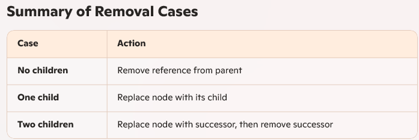

**Remove Consolidated**

```python
# Python class definitions for a Binary Search Tree (BST) and its nodes
# We define Node and BinarySearchTree classes because they provide the structure & functionality necessary to build &
# manipulate a binary search tree efficiently
# Node Represents a single element in the tree. Holds a value, and links to left and right children.
# Node Does not need a root because nodes are just building blocks.
class Node:
    def __init__(self, value):
        self.value = value # Stores the node's value
        self.left = None   # Left child (smaller values)
        self.right = None  # Right child (larger values)
# Without this class, there would be no way to create and manage individual nodes!

# A binary search tree represents the entire tree structure and is a collection of nodes, and it needs a way to:
# a.Insert values efficiently b.Search for values c.Remove values while maintaining tree structure
class BinarySearchTree:
    def __init__(self):
        self.root = None
# All operations(insert,remove,search & traversal) will be performed on self.root and its children. Without this class, nodes
# wouldn’t be connected into a meaningful tree structure! 🌳
# Think of Node as bricks and BinarySearchTree as the blueprint that organizes them into a house🏠

        50
       /  \
     30    70
    /  \   /  \
   20  40 60  80
      /  \
     35  45
    /    /
   34   42

# Below method removes a node with the given value from the binary search tree
# start- The node where the search begins (default is self.root)
# parent- Keeps track of the parent node.
    def remove(self, value, start=None, parent=None):
        current = start or self.root # If start is provided, use it; otherwise, start from the root.
# In Python, "or" returns the first truthy value or the last value if all are falsy.This behavior is known as short-circuiting,
# meaning Python stops evaluating once it finds a truthy value

       """ Step 1: Find the node to remove """
        while current and current.value != value: #Loop until we find the node with the given value(current.value) or reach the end(current(node) = None)
            # if current becomes none , Python treats none as False and stops the loop.

            parent = current # Keep track of the parent node before moving left or right,so that, when we find the target node (current),
                             # we know who its parent is & we know how to adjust its parent's link.
            if value < current.value: # If the value is smaller, move to the left child (per Binary Tree logic)
                current = current.left
            else:
                current = current.right # If the value is higher, move to the right child

       """ Step 2: If node is not found, raise an exception """
        if not current: # e.g if 4 < 5 but 5 has no left node then current =current.left will return None, which makes "if not current"condition as TRUE
            raise Exception("Item not in tree") # If we reach None, the value is not in the tree, so we raise an error.
# "not" operator checks if a value is False or None. Since current is a Node or None, a) If current exists (is not None) → The condition is False,
# and the program continues. b) If current doesn't exist (is None) → The condition is True, and we raise an exception.

       """ Step 3: Handle different cases based on the number of children """
        if not current.left and not current.right: # if current node has no left or right child
            return self._remove_node_no_children(current, parent) #If the node has no children, call _remove_node_no_children

        if current.left and current.right: # if current node has both left and right child
            return self._remove_node_two_children(current) # If the node has two children, call _remove_node_two_children
        return self._remove_node_one_child(current, parent)# If the node has one child, call _remove_node_one_child.

# All remove child subfunctions are using "_" e.g _remove_node.. which indicates private helper fn, which keeps these internal fns hidden & prevents
# external users from accessing it. It also helps in better & clean code mgmt , breaks down complex tasks into smaller, reusable functions
     def _remove_node_no_children(self, current, parent):
        """Removes a node with no children."""
        if current is self.root:
            self.root = None # If the node is the root, set self.root = None (tree becomes empty).
            return self
        if parent.left == current:
            parent.left = None # If the node is the left child of its parent, remove it by setting parent.left = None.
        else:
            parent.right = None # If the node is the right child of its parent, remove it by setting parent.right = None.
        return self

    def _remove_node_one_child(self, current, parent):
        """Removes a node with one child."""
# Logic : 1. Check if the child (of Current) is on right or left (since we are looking for only 1 child)
# 2. If right then point Parent.right to child else left

# old version of coding`
#  if current.right:
#       child = current.right
#  else:
#       child = current.left
        child = current.right if current.right else current.left # If current has a right child, child is assigned current.right.
# If current doesn't have a right child, but has a left child, child is assigned current.left. If neither exists, child will be None,
# but in this function, we know it has one child, so this ensures proper replacement.
        if current is self.root:    # If current is the root node, we need to replace it directly with its child.
            self.root = child       # ensures the tree still has a valid structure.
            return self             # Then, we return self, since there's no need to modify parent-child links further.
        if parent.right == current: # If the current node is the right child of its parent,
            parent.right = child    # replace it with its own child which was also right of current.
        else:
            parent.left = child     # If the node is the left child of its parent,replace it with its own child which was also left of current.
        return self # Return the updated tree.Think of self as the bridge that connects individual objects to the blueprint(class) they come from.

# static method is a function inside a class that Does not need access to instance variables(self) or class variables(cls).It can be called directly
# from the class,without needing to create an instance.It Works as a utility function related to the class but independent of instance properties.
    @staticmethod
    def _get_successor(current): # Need a value larger than node being deleted, which lives in the right subtree.
# The leftmost node in the right subtree is the smallest of the values larger than the node, making it the in-order successor.
# The successor we are adopting(in-order successor vs predecessor) should be Higher than current (go right) but lower than right child (now go left)
        """Finds the successor (smallest node in the right subtree)."""
        successor = current.right # Start from the right child of the current node(to access larger values - right of root)
        while successor and successor.left: # 1.Check if successor exists(not None) & 2.checks if successor.left exists.
            successor = successor.left # Move left until we find the smallest node among them
        return successor # Return the successor node.

#We are using "self._get_successor",calling it from the instance,but it doesn’t rely on self internally,because it's defined as @staticmethod
# you can also write it like "BinarySearchTree._get_successor(current)" since _get_successor method belongs to the class,
# but it doesn’t depend on instance (self) or class (cls) variables
    def _remove_node_two_children(self, current):
        """Removes a node with two children."""
        successor = self._get_successor(current) # Find the successor (smallest node in the right subtree). The result is assigned the name 'successor'
        current.value = successor.value #Instead of deleting current,we overwrite its value with successor.value.This avoids breaking the BST structure.
        return self.remove(successor.value, start=current.right, parent=current)
# current.value & successor.value are not nodes but integers, since integers are immutable. python copies the value, not a reference
# if it was current = successor, current would now refer to the entire successor node, not just its value. This would make current a new reference,
# not an overwrite. And now that current(40) is replaced/overwritten with successor.value (42), we still have the original 42(child of 45) which
# needs to be removed , but instead of handling this removal separately, we call "remove" recursively to let the existing logic take care of it.
# Since 42 is a leaf node (no children), a diff function "_remove_nod_no_children" will be activated to address that & the final output will be as below
# since there will be two 42 in the tree (havent deleted leaf 42 yet), hence we use the start value as current.right and use current as parent

# Before removing 40
       50
       /  \
     30    70
    /  \   /  \
   20  40 60  80
      /  \
     35  45
    /    /
   34   42

# After replacing 40 with 42
        50
       /  \
     30    70
    /  \   /  \
   20  42 60  80
      /  \
     35  45
    /
   34
```

### Real-Life Applications of Binary Search Trees (BSTs)

Binary Search Trees (BSTs) are widely used in systems where fast searching, insertion, and deletion of sorted data is critical. Their ordered structure makes them ideal for indexing, hierarchical data storage, and efficient lookups.

#### 🔑 Key Applications

##### 1. Databases & Indexing

- **Database Indexes**: BSTs (often in the form of B-Trees or B+ Trees) maintain sorted indexes for quick search, insert, and delete operations.
- **Range Queries**: Efficient retrieval of records within a range (e.g., customers with IDs between 1000 and 2000).
- **Primary & Secondary Indexes**: Organize both primary keys and secondary attributes for faster query execution.

##### 2. File Systems & Operating Systems

- **Directory Structures**: Store hierarchical file paths for quick navigation.
- **Memory Management**: Manage free memory blocks for efficient allocation and deallocation.

##### 3. Compilers & Expression Parsing

- **Syntax Trees**: Abstract Syntax Trees (ASTs) represent program code for parsing and optimization.
- **Symbol Tables**: Store variable/function names in sorted order for fast lookup during compilation.

##### 4. Networking & Distributed Systems

- **Routing Tables**: Organize routing information for efficient packet forwarding.
- **Load Balancing**: Maintain sorted lists of servers/resources for quick allocation.

##### 5. Search Engines & Information Retrieval

- **Keyword Indexing**: Store keywords in sorted order for fast document retrieval.
- **Autocomplete Features**: BSTs (or variants like Tries + BSTs) suggest results in search bars.

##### 6. Finance & E-commerce

- **Stock Market Systems**: Maintain sorted lists of stock prices for quick lookups and range queries.
- **Product Catalogs**: Organize products by price, rating, or category for efficient filtering.

#### 📊 Comparison Table

| Application Area | BST Role | Example Use Case |
| --- | --- | --- |
| Databases | Indexing, range queries | SQL query optimization |
| File Systems | Directory & memory management | Linux file system navigation |
| Compilers | Syntax & symbol tables | Parsing expressions |
| Networking | Routing & load balancing | IP routing tables |
| Search Engines | Keyword indexing, autocomplete | Google search suggestions |
| Finance/E-commerce | Sorted product/price lists | Amazon product filtering |

#### ⚠️ Trade-offs & Limitations

- **Unbalanced BSTs** can degrade performance to `O(n)` (like a linked list).
- **Self-balancing BSTs** (AVL, Red-Black Trees) are often used in practice to maintain efficiency.
- **Memory overhead**: BSTs require extra pointers, which can be costly in memory-constrained systems.